# Some basic analysis for our death penalty project

```r
library(data.table)
library(tidyverse)
library(lubridate)
`%notlike%` <- Negate(`%like%`)

`%notin%`<- Negate(`%in%`)
```

# Imports, some basic looking at things, and a simple chart

```r
# grabbing data from the db.
join_files <- list.files("/mnt/c/Users/m/projects/cnki_database/tbls/run_5", pattern = "tbl_join", full.names = TRUE)

main_db <- fread("/mnt/c/Users/m/projects/cnki_database/tbls/merged/tbl_final_to_run_8.csv")

setnames(main_db, "document_id", "doc_id")

readdata <- function(x){
    dt_csv <- fread(x, encoding = "UTF-8", header = TRUE)[,-c("V1")]
    keycols <- c("document_id")
    setkeyv(dt_csv, keycols)
    return(dt_csv)
}

mylist <- lapply(join_files, readdata)
dt_join <- rbindlist(mylist, use.names = TRUE, fill = TRUE)

setnames(dt_join, "document_id", "doc_id")

dt <- main_db[dt_join, on = "doc_id"]
```

# What were the search terms in the db?

This shows them plus the field. Forget the NA value.

```r
dt[,unique(search_term)]
```

```
## [1] NA                              "yifazhiguo_keyword"
## [3] "kuanyanxiangji_abstract"       "yishenpanweizhongxin_abstract"
## [5] "yanda_abstract"                "sixing_abstract"
## [7] "sihuan_abstract"               "sixing_keywords"
## [9] "shaoshashensha_abstract"
```

```r
# all the column names
names(dt)
```

```
##  [1] "V1"                    "art"                   "doc_id"
##  [4] "title_ch"              "title_en"              "authors_en"
##  [7] "funding"               "journal"               "journal_year"
## [10] "journal_issue"         "keywords_en"           "abstract_ch"
## [13] "abstract_en"           "classification_number" "downloads"
## [16] "pdf_url"               "pdf_new_name"          "author_ch"
## [19] "run"                   "institutions"          "keywords"
## [22] "search_term"
```

# A simple plot of the pubs

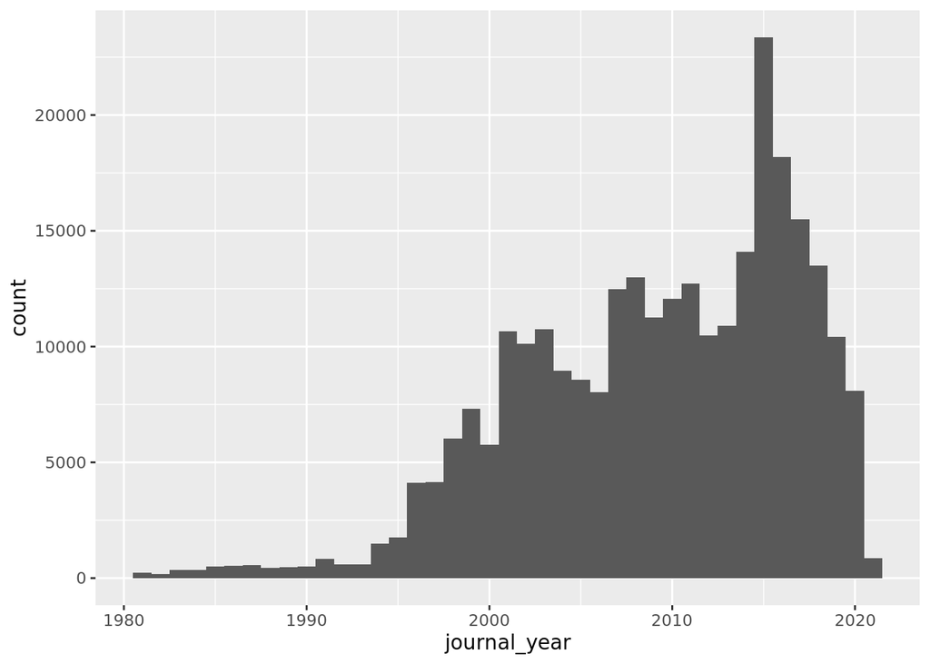

```r
dt[journal_year > 1980] %>%
  ggplot(aes(journal_year)) +
  geom_histogram(binwidth = 1)
```

```r
# read in that data.
df_sifa_pubdates <- fread("/mnt/c/Users/m/projects/cnki_database/data/run_10/raw_html_pages/sifa_pubdates.txt")
# note the above was created from the htmls with the command rg -o [0-9]{4}-[0-9]{2}-[0-9]{2} 0*.html | rg -o [0-9]{4}-[0-9]{2}-[0-9]{2} and that was output to that text file.
```

# An attempted normalisation of this data per pubs that /mention/ criminal justice

Think the idea here is that the broader universe of all pubs mentioning 刑事司法 anywhere in them are going to be a kind of control on whether there’s anything funny going on in these data.

Note that these are two different datasets – though with some overlap. The first is the entire dataset with all the terms about death penalty/criminal justice. Below are ALL articles that even /mentioned/ it anywhere in it. The n is 97029. The n of the first is 281943.

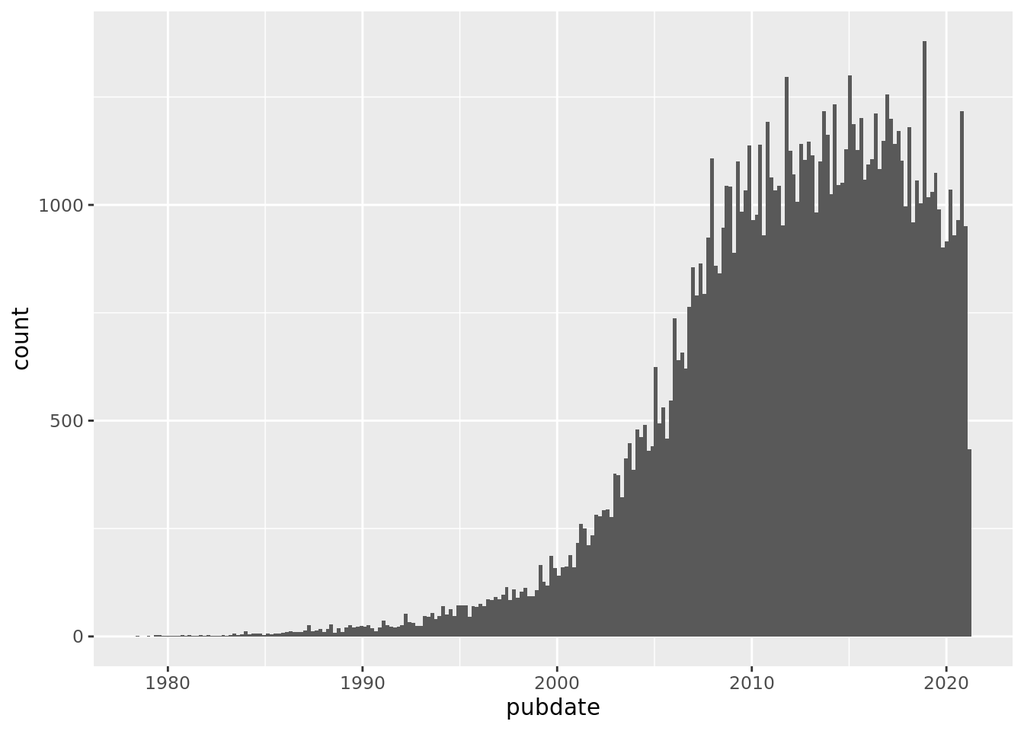

```r
setnames(df_sifa_pubdates, "V1", "pubdate")

df_sifa_pubdates[,pubdate := ymd(pubdate)]

df_sifa_pubdates[pubdate > 1980-01-01] %>%
  ggplot(aes(pubdate)) +
  geom_histogram(binwidth = 70)
```

# about scaling/standardizing/normalising the data

The initial issue we had with this data was: what if ALL of the cnki data goes up and down almost exactly like that, due to some exogenous factor (like the leadership said: we need x more pubs every year for the next 10 years, then we need y less more every year after that), and the entire academic output of China followed that trajectory, then our variation in DP stuff would be meaningless. So we want to compare it to something to see if the variation is meaningful.

I think we can just show the two graphs side by side – the dp one and the one with crim justice ANYWHERE in it – and it will be clear that the DP one has gone down. One way of quantifying this change is by a correlation analysis – a bivariate regression, I’m told – where you get a number that measures how closely two distributions correspond… but it hardly seems necessary and would be weird/funny for us to do that. Since anyone can use their eyes to look and see that one goes up and down and the other goes up and doesn’t go down.

# Some analysis of funding

This just pulls out all the cases where there is a report of funding, and plots on the year.

```r
dt[,.(funding)][,uniqueN(funding)]
```

```
## [1] 4985
```

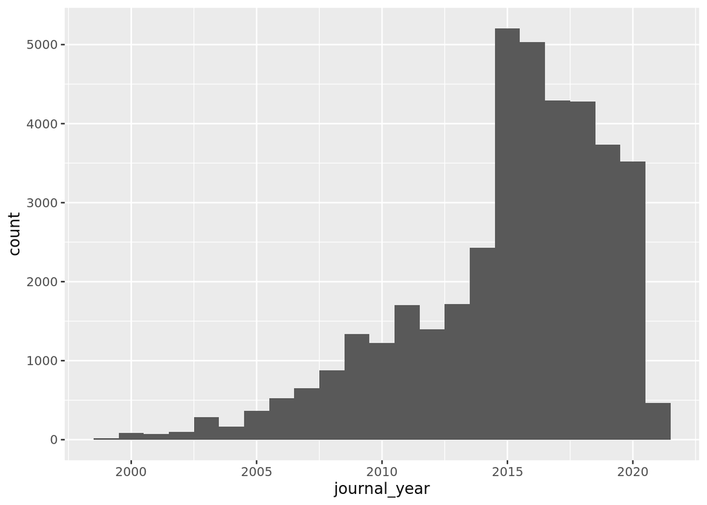

```r
dt[funding != ""] %>%
  ggplot(aes(journal_year)) +
  geom_histogram(binwidth = 1)
```

Now trying the same for death penalty only. First just the publication distribution…. for all time and then just post 1980 then post 2000

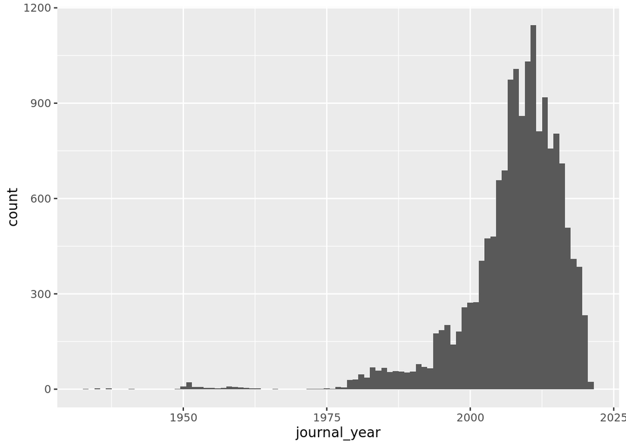

```r
dt[search_term %like% "sixing"] %>%
  ggplot(aes(journal_year)) +
  geom_histogram(binwidth = 1)
```

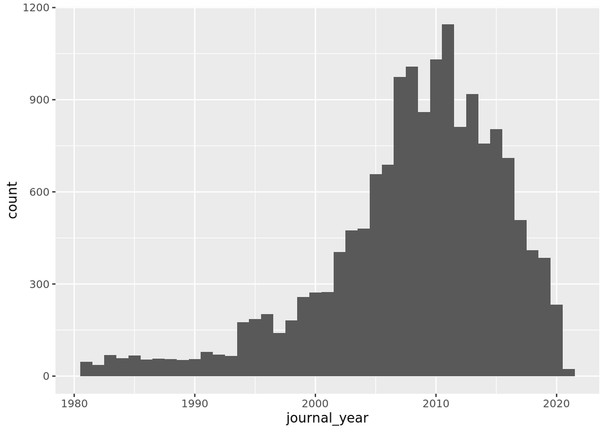

```r
dt[search_term %like% "sixing"][journal_year > 1980] %>%
  ggplot(aes(journal_year)) +
  geom_histogram(binwidth = 1)
```

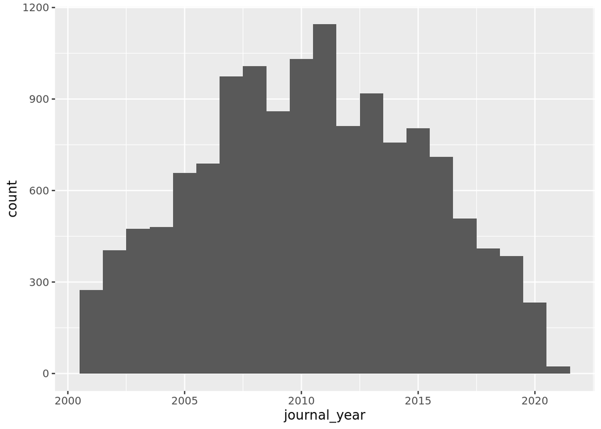

```r
dt[search_term %like% "sixing"][journal_year > 2000] %>%
  ggplot(aes(journal_year)) +
  geom_histogram(binwidth = 1)
```

Now the funding count per year.

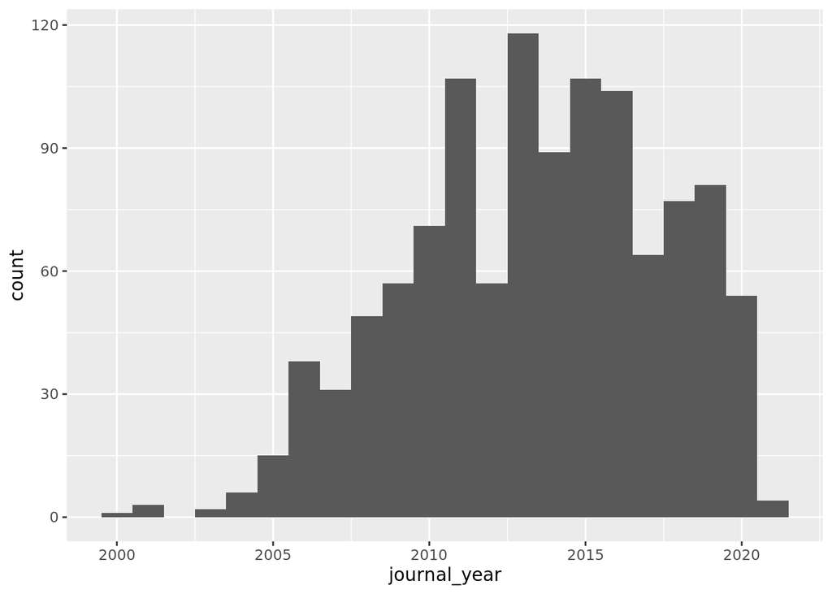

```r
dt[search_term %like% "sixing"][funding != ""] %>%
  ggplot(aes(journal_year)) +
  geom_histogram(binwidth = 1)
```

# Who is doing the funding?

If you just unique ALL of the different funding agencies, the list is massive. We can’t figure out who is funding what like that. I’ll try get some topn counts.

```r
dt[,unique(funding)] %>% head(50)
```

```
##  [1] "国家社会科学基金一般项目“依法治国的中国传统法律文化溯源研究”（19BFX021）;天津市研究生科研创新项目“马克思主义法律思想在中国早期的传播研究（1899-1937）”(2019YJSB026）"
##  [2] "重庆市第四批哲学社会科学领军人才特殊支持计划项目“新时代刑法的社会治理功能研究”"
##  [3] ""
##  [4] "国家社会科学基金重大项目“新时代诚信建设制度化的深化和创新研究”（项目编号：18VSJ082"
##  [5] "国家社会科学基金重大项目“中国特色刑事证据理论体系研究”（18ZDA139）阶段性成果;教育部人文社会科学青年基金项目“中国语境下鉴真规则适用研究”（19YJC820052）阶段性成果"
##  [6] "浙江省高等教育“十三五”第二批教学改革研究项目(jg20190389);杭州师范大学教改项目"
##  [7] "国家社科基金重大专项“推动社会主义协商民主广泛多层制度化发展研究”的阶段性研究成果，项目编号：18VSJ025"
##  [8] "国家社会科学基金一般项目（15BFX072）;山东省社会科学规划研究课题（18CSPJ01）;青岛市社会科学规划项目（QDSKL1901134）"
##  [9] "中国法学会2019年度部级法学研究课题“国家安全法治视野下管辖海域的刑事立法研究”(CLS2019D23)"
## [10] "鞍山师范学院科研基金资助项目"
## [11] "公安部科研资助!项目( 993203300)"
## [12] "河北省哲学社会科学规划基金项目! ( 19980 4 0 0 1)"
## [13] "1999年省教委基金"
## [14] "国家自然科学基金!项目号：79730010"
## [15] "国家重点攻关项目! (96   0 0 4  0 5   1 3)中的一部分内容"
```

[output cut: 35 more lines]

```r
#meaning there are only
dt[,uniqueN(funding)]
```

```
## [1] 4985
```

```r
# this is not very informative.
dt[,.(funding_count = .N), by = funding]
```

| funding | funding_count |
| --- | --- |
| 国家社会科学基金一般项目“依法治国的中国传统法律文化溯源研究”（19BFX021）;天津市研究生科研创新项目“马克思主义法律思想在中国早期的传播研究（1899-1937）”(2019YJSB026） | 10 |
| 重庆市第四批哲学社会科学领军人才特殊支持计划项目“新时代刑法的社会治理功能研究” | 9 |
|  | 242394 |
| 国家社会科学基金重大项目“新时代诚信建设制度化的深化和创新研究”（项目编号：18VSJ082 | 13 |
| 国家社会科学基金重大项目“中国特色刑事证据理论体系研究”（18ZDA139）阶段性成果;教育部人文社会科学青年基金项目“中国语境下鉴真规则适用研究”（19YJC820052）阶段性成果 | 7 |
| 浙江省高等教育“十三五”第二批教学改革研究项目(jg20190389);杭州师范大学教改项目 | 10 |
| 国家社科基金重大专项“推动社会主义协商民主广泛多层制度化发展研究”的阶段性研究成果，项目编号：18VSJ025 | 8 |
| 国家社会科学基金一般项目（15BFX072）;山东省社会科学规划研究课题（18CSPJ01）;青岛市社会科学规划项目（QDSKL1901134） | 9 |
| 中国法学会2019年度部级法学研究课题“国家安全法治视野下管辖海域的刑事立法研究”(CLS2019D23) | 7 |
| 鞍山师范学院科研基金资助项目 | 6 |

[output cut: 4975 more lines]

looking at a few, some ideas for funding source TYPES might be…

```r
funding_sources <- c("教育部","国家社会科学基金","省|市","中国法学会", "大学|学院|研究所|研究院")

dt_w_funding <- dt[,.(funding = unique(funding)), by = .(doc_id, journal_year, search_term)][funding %like% "教育部",funding_source := "MOE"]
dt_w_funding[funding %like% "国家社会科|国家社科",funding_source := "CASS"]
dt_w_funding[funding %like% "省|市",funding_source := "province_or_city"]
dt_w_funding[funding %like% "大学|学院|研究所|研究院",funding_source := "university"]
dt_w_funding[funding %like% "中国法学会",funding_source := "China_law_society"]
dt_w_funding[funding %like% "国家",funding_source := "central_govt"]

dt_w_funding[,unique(funding_source)]
```

```
## [1] "central_govt"      "province_or_city"  NA
## [4] "university"        "MOE"               "China_law_society"
```

```r
dt_w_funding[,.(funding_count = .N), by = .(funding, funding_source, journal_year)]
```

| funding | funding_source | journal_year | funding_count |
| --- | --- | --- | --- |
| 国家社会科学基金一般项目“依法治国的中国传统法律文化溯源研究”（19BFX021）;天津市研究生科研创新项目“马克思主义法律思想在中国早期的传播研究（1899-1937）”(2019YJSB026） | central_govt | NA | 2 |
| 重庆市第四批哲学社会科学领军人才特殊支持计划项目“新时代刑法的社会治理功能研究” | province_or_city | NA | 2 |
|  | NA | NA | 57 |
| 国家社会科学基金重大项目“新时代诚信建设制度化的深化和创新研究”（项目编号：18VSJ082 | central_govt | NA | 2 |
| 国家社会科学基金重大项目“中国特色刑事证据理论体系研究”（18ZDA139）阶段性成果;教育部人文社会科学青年基金项目“中国语境下鉴真规则适用研究”（19YJC820052）阶段性成果 | central_govt | NA | 2 |
| 浙江省高等教育“十三五”第二批教学改革研究项目(jg20190389);杭州师范大学教改项目 | university | NA | 2 |
|  | NA | 2021 | 122 |
| 国家社科基金重大专项“推动社会主义协商民主广泛多层制度化发展研究”的阶段性研究成果，项目编号：18VSJ025 | central_govt | NA | 2 |
| 国家社会科学基金一般项目（15BFX072）;山东省社会科学规划研究课题（18CSPJ01）;青岛市社会科学规划项目（QDSKL1901134） | central_govt | NA | 2 |
| 中国法学会2019年度部级法学研究课题“国家安全法治视野下管辖海域的刑事立法研究”(CLS2019D23) | central_govt | NA | 2 |

[output cut: 5088 more lines]

```r
dt_w_funding[,.(funding_count = .N), by = .(funding_source)]
```

| funding_source | funding_count |
| --- | --- |
| central_govt | 3585 |
| province_or_city | 2962 |
| NA | 73445 |
| university | 2307 |
| MOE | 646 |
| China_law_society | 186 |

These are for death penalty funding specifically.

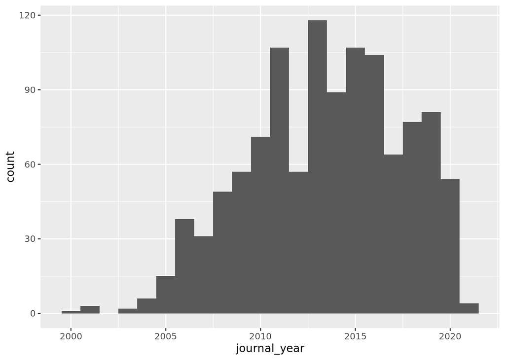

```r
dt_w_funding[search_term %like% "sixing"][funding != ""] %>%
  ggplot(aes(journal_year)) +
  geom_histogram(binwidth = 1)
```

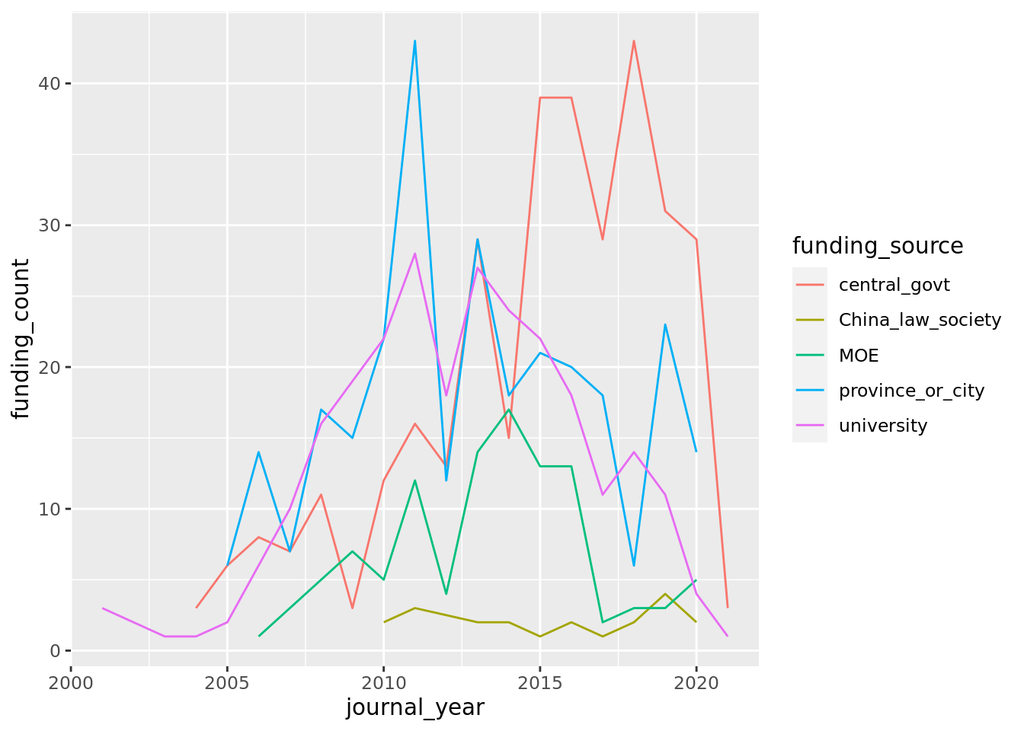

```r
dt_w_funding[search_term %like% "sixing"][,.(funding_count = .N), by = .(funding_source, journal_year)
   ][funding_source != ""][funding_source != "NA"] %>%
  ggplot(aes(journal_year, funding_count, colour = funding_source)) +
  geom_line()
```

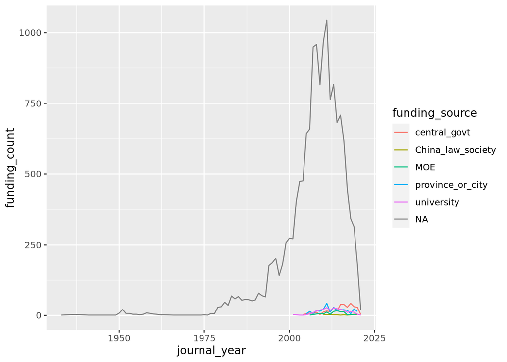

```r
# but the vast majority don't state funding!!
dt_w_funding[search_term %like% "sixing"][,.(funding_count = .N), by = .(funding_source, journal_year)
   ] %>%
  ggplot(aes(journal_year, funding_count, colour = funding_source)) +
  geom_line()
```

UPDATE: OK, I didn’t yet put in central govt stuff and I didn’t have as expansive a definition of CASS. So those were more.

Not sure if there is more juice to squeeze on the funding. Basically the vast majority don’t even state the funding, so any variation there is going to be just eclipsed by all the ones that don’t state. Definitely spent too long on that avenue!!

# Analysis of criminal justice slogans in full text death penalty academic publications